# Results

Paulo Guimarães

2025-10-19

## Descriptive Analysis

In this first chunk, I present the results of summary statistics and respective plots for the target variable (monthly Realized Variance - RV) and the covariates.

First we source helpers and classes functions and load datasets

```r
  ## Helpers and classes
  source(file.path(here::here(), "R", "helpers.R"))
  source(file.path(here::here(), "R", "classes.R"))

  ## Load datasets
    ### Covariates
    covariates_1927_df <- readRDS(file.path(here::here(),
                                            "data", "covariates_1927.rds"))
    covariates_1986_df <- readRDS(file.path(here::here(),
                                            "data", "covariates_1986.rds"))

    ### Target
    target             <- readRDS(file.path(here::here(),
                                            "data", "crsp_monthly.rds"))
  ## For plots
  grDevices::windowsFonts(Helvetica = grDevices::windowsFont("Arial"))
```

First I present summary tables for covariates since 1927, then covariates since 1987, which contains all variables, including implied volatility. The list of covariates can be grouped follows:

```r
    ## Apply!
    summary_1927   <- make_var_summary(covariates_1927_df)
    summary_1986   <- make_var_summary(covariates_1986_df)
    summary_target <- make_var_summary(target)

    summary_1927
```

Summary Statistics of Covariates

Monthly sample; per-series effective sample periods

| Series | Start | End | Span (yrs) | N | N miss | Mean | SD | P10 | Median | P90 | Min | Max | ACF(1) |
| --- | --- | --- | --- | --- | --- | --- | --- | --- | --- | --- | --- | --- | --- |
| cont_month_lag1 | Sat, Jan 1, 1927 | Sun, Dec 1, 2024 | 97.9165 | 1,176 | 0 | 0.0001 | 0.0001 | 0.0000 | 0.0000 | 0.0001 | 0.0000 | 0.0027 | 0.5154 |
| cont_td_lag1 | Sat, Jan 1, 1927 | Sun, Dec 1, 2024 | 97.9165 | 1,176 | 0 | 0.0014 | 0.0052 | 0.0000 | 0.0002 | 0.0031 | 0.0000 | 0.0988 | 0.0616 |
| cont_tw_lag1 | Sat, Jan 1, 1927 | Sun, Dec 1, 2024 | 97.9165 | 1,176 | 0 | 0.0003 | 0.0010 | 0.0000 | 0.0001 | 0.0006 | 0.0000 | 0.0293 | 0.1571 |
| dy_lag1 | Sat, Jan 1, 1927 | Sun, Dec 1, 2024 | 97.9165 | 1,176 | 0 | 0.0364 | 0.0173 | 0.0166 | 0.0339 | 0.0593 | 0.0111 | 0.1384 | 0.9879 |
| ey_lag1 | Sat, Jan 1, 1927 | Sun, Dec 1, 2024 | 97.9165 | 1,176 | 0 | 0.0681 | 0.0285 | 0.0392 | 0.0597 | 0.1110 | 0.0081 | 0.1718 | 0.9914 |
| gpr_lag1 | Sat, Jan 1, 1927 | Sun, Dec 1, 2024 | 97.9165 | 1,176 | 0 | 0.0011 | 0.2197 | −0.2419 | −0.0089 | 0.2447 | −0.8257 | 2.0513 | −0.1799 |
| ip_vol | Sat, Jan 1, 1927 | Sun, Dec 1, 2024 | 97.9165 | 1,176 | 0 | 5.6094 | 2.9388 | 2.9783 | 4.8401 | 9.1753 | 0.0000 | 28.0277 | 0.6022 |
| jump_month_lag1 | Sat, Jan 1, 1927 | Sun, Dec 1, 2024 | 97.9165 | 1,176 | 0 | 0.0000 | 0.0001 | 0.0000 | 0.0000 | 0.0001 | 0.0000 | 0.0020 | 0.3677 |
| jump_td_lag1 | Sat, Jan 1, 1927 | Sun, Dec 1, 2024 | 97.9165 | 1,176 | 0 | 0.0007 | 0.0031 | 0.0000 | 0.0000 | 0.0013 | 0.0000 | 0.0518 | 0.1467 |
| jump_tw_lag1 | Sat, Jan 1, 1927 | Sun, Dec 1, 2024 | 97.9165 | 1,176 | 0 | 0.0002 | 0.0005 | 0.0000 | 0.0001 | 0.0004 | 0.0000 | 0.0109 | 0.1126 |
| log_epu_diff_lag1 | Sat, Jan 1, 1927 | Sun, Dec 1, 2024 | 97.9165 | 1,176 | 0 | 0.0008 | 0.2437 | −0.2875 | −0.0153 | 0.3145 | −0.9189 | 1.0765 | −0.2925 |
| negret_month_lag1 | Sat, Jan 1, 1927 | Sun, Dec 1, 2024 | 97.9165 | 1,176 | 0 | −0.0148 | 0.0319 | −0.0508 | 0.0000 | 0.0000 | −0.3352 | 0.0000 | 0.1493 |
| negret_td_lag1 | Sat, Jan 1, 1927 | Sun, Dec 1, 2024 | 97.9165 | 1,176 | 0 | −0.0564 | 0.1300 | −0.1841 | 0.0000 | 0.0000 | −1.5064 | 0.0000 | 0.1236 |
| negret_tw_lag1 | Sat, Jan 1, 1927 | Sun, Dec 1, 2024 | 97.9165 | 1,176 | 0 | −0.0303 | 0.0616 | −0.1001 | 0.0000 | 0.0000 | −0.5758 | 0.0000 | 0.0772 |
| ppi_vol | Sat, Jan 1, 1927 | Sun, Dec 1, 2024 | 97.9165 | 1,176 | 0 | 2.4159 | 1.3170 | 1.1565 | 2.1181 | 3.9600 | 0.3275 | 10.6068 | 0.6368 |
| rq_month_lag1 | Sat, Jan 1, 1927 | Sun, Dec 1, 2024 | 97.9165 | 1,176 | 0 | 0.0000 | 0.0000 | 0.0000 | 0.0000 | 0.0000 | 0.0000 | 0.0000 | 0.1494 |
| rq_td_lag1 | Sat, Jan 1, 1927 | Sun, Dec 1, 2024 | 97.9165 | 1,176 | 0 | 0.0000 | 0.0000 | 0.0000 | 0.0000 | 0.0000 | 0.0000 | 0.0002 | 0.0100 |
| rq_tw_lag1 | Sat, Jan 1, 1927 | Sun, Dec 1, 2024 | 97.9165 | 1,176 | 0 | 0.0000 | 0.0000 | 0.0000 | 0.0000 | 0.0000 | 0.0000 | 0.0002 | 0.0193 |
| rv_month_lag1 | Sat, Jan 1, 1927 | Sun, Dec 1, 2024 | 97.9165 | 1,176 | 0 | 0.0025 | 0.0052 | 0.0004 | 0.0011 | 0.0052 | 0.0001 | 0.0712 | 0.5589 |
| rv_td_lag1 | Sat, Jan 1, 1927 | Sun, Dec 1, 2024 | 97.9165 | 1,176 | 0 | 0.0021 | 0.0069 | 0.0000 | 0.0004 | 0.0046 | 0.0000 | 0.1031 | 0.0995 |
| rv_tw_lag1 | Sat, Jan 1, 1927 | Sun, Dec 1, 2024 | 97.9165 | 1,176 | 0 | 0.0024 | 0.0073 | 0.0002 | 0.0009 | 0.0053 | 0.0000 | 0.2011 | 0.1579 |
| sqrt_days | Sat, Jan 1, 1927 | Sun, Dec 1, 2024 | 97.9165 | 1,176 | 0 | 4.6742 | 0.2210 | 4.4721 | 4.6904 | 5.0000 | 3.8730 | 5.1962 | 0.4411 |

```r
    summary_1986
```

Summary Statistics of Covariates

Monthly sample; per-series effective sample periods

| Series | Start | End | Span (yrs) | N | N miss | Mean | SD | P10 | Median | P90 | Min | Max | ACF(1) |
| --- | --- | --- | --- | --- | --- | --- | --- | --- | --- | --- | --- | --- | --- |
| cont_month_lag1 | Sat, Feb 1, 1986 | Sun, Dec 1, 2024 | 38.8309 | 467 | 0 | 0.0001 | 0.0002 | 0.0000 | 0.0000 | 0.0002 | 0.0000 | 0.0027 | 0.3984 |
| cont_td_lag1 | Sat, Feb 1, 1986 | Sun, Dec 1, 2024 | 38.8309 | 467 | 0 | 0.0015 | 0.0041 | 0.0000 | 0.0003 | 0.0036 | 0.0000 | 0.0483 | 0.1546 |
| cont_tw_lag1 | Sat, Feb 1, 1986 | Sun, Dec 1, 2024 | 38.8309 | 467 | 0 | 0.0003 | 0.0007 | 0.0000 | 0.0001 | 0.0007 | 0.0000 | 0.0080 | 0.5363 |
| dfr_lag1 | Sat, Feb 1, 1986 | Sun, Dec 1, 2024 | 38.8309 | 467 | 0 | 1.3246 | 0.4507 | 0.7900 | 1.2800 | 1.9100 | 0.4400 | 2.6800 | 0.9598 |
| dfy_lag1 | Sat, Feb 1, 1986 | Sun, Dec 1, 2024 | 38.8309 | 467 | 0 | 2.2935 | 0.6919 | 1.5660 | 2.1700 | 3.1440 | 1.2900 | 6.0100 | 0.9659 |
| dy_lag1 | Sat, Feb 1, 1986 | Sun, Dec 1, 2024 | 38.8309 | 467 | 0 | 0.0212 | 0.0067 | 0.0136 | 0.0195 | 0.0323 | 0.0111 | 0.0388 | 0.9857 |
| ey_lag1 | Sat, Feb 1, 1986 | Sun, Dec 1, 2024 | 38.8309 | 467 | 0 | 0.0479 | 0.0138 | 0.0319 | 0.0463 | 0.0651 | 0.0081 | 0.0864 | 0.9854 |
| gpr_lag1 | Sat, Feb 1, 1986 | Sun, Dec 1, 2024 | 38.8309 | 467 | 0 | 0.0006 | 0.2304 | −0.2390 | −0.0092 | 0.2197 | −0.8257 | 2.0513 | −0.1623 |
| ip_vol | Sat, Feb 1, 1986 | Sun, Dec 1, 2024 | 38.8309 | 467 | 0 | 4.3270 | 1.7195 | 2.7080 | 4.0705 | 5.8232 | 1.2712 | 16.0742 | 0.6174 |
| jump_month_lag1 | Sat, Feb 1, 1986 | Sun, Dec 1, 2024 | 38.8309 | 467 | 0 | 0.0000 | 0.0001 | 0.0000 | 0.0000 | 0.0001 | 0.0000 | 0.0020 | 0.2203 |
| jump_td_lag1 | Sat, Feb 1, 1986 | Sun, Dec 1, 2024 | 38.8309 | 467 | 0 | 0.0008 | 0.0035 | 0.0000 | 0.0000 | 0.0013 | 0.0000 | 0.0476 | 0.1952 |
| jump_tw_lag1 | Sat, Feb 1, 1986 | Sun, Dec 1, 2024 | 38.8309 | 467 | 0 | 0.0002 | 0.0005 | 0.0000 | 0.0001 | 0.0004 | 0.0000 | 0.0071 | 0.1991 |
| log_cons_sent_diff_lag1 | Sat, Feb 1, 1986 | Sun, Dec 1, 2024 | 38.8309 | 467 | 0 | −0.0006 | 0.0511 | −0.0573 | −0.0021 | 0.0569 | −0.2159 | 0.2197 | 0.0151 |
| log_epu_diff_lag1 | Sat, Feb 1, 1986 | Sun, Dec 1, 2024 | 38.8309 | 467 | 0 | 0.0016 | 0.2603 | −0.3104 | −0.0119 | 0.3029 | −0.9189 | 1.0765 | −0.2419 |
| mbas_vol | Sat, Feb 1, 1986 | Sun, Dec 1, 2024 | 38.8309 | 467 | 0 | 3.4165 | 4.2671 | 0.8630 | 1.3940 | 8.5589 | 0.0000 | 26.0429 | 0.5008 |
| negret_month_lag1 | Sat, Feb 1, 1986 | Sun, Dec 1, 2024 | 38.8309 | 467 | 0 | −0.0129 | 0.0272 | −0.0469 | 0.0000 | 0.0000 | −0.2268 | 0.0000 | 0.1585 |
| negret_td_lag1 | Sat, Feb 1, 1986 | Sun, Dec 1, 2024 | 38.8309 | 467 | 0 | −0.0665 | 0.1373 | −0.2137 | 0.0000 | 0.0000 | −1.4499 | 0.0000 | 0.1953 |
| negret_tw_lag1 | Sat, Feb 1, 1986 | Sun, Dec 1, 2024 | 38.8309 | 467 | 0 | −0.0251 | 0.0558 | −0.0890 | 0.0000 | 0.0000 | −0.5710 | 0.0000 | 0.0637 |
| oil_rv_month_lag1 | Sat, Feb 1, 1986 | Sun, Dec 1, 2024 | 38.8309 | 467 | 0 | 0.0145 | 0.0373 | 0.0027 | 0.0074 | 0.0234 | 0.0010 | 0.5500 | 0.5024 |
| oil_rv_td_lag1 | Sat, Feb 1, 1986 | Fri, Nov 1, 2024 | 38.7488 | 434 | 33 | 0.0218 | 0.1637 | 0.0001 | 0.0028 | 0.0280 | 0.0000 | 3.0894 | 0.3653 |
| oil_rv_tw_lag1 | Sat, Feb 1, 1986 | Sun, Dec 1, 2024 | 38.8309 | 467 | 0 | 0.0158 | 0.0574 | 0.0012 | 0.0058 | 0.0309 | 0.0001 | 0.8976 | 0.4776 |
| ppi_vol | Sat, Feb 1, 1986 | Sun, Dec 1, 2024 | 38.8309 | 467 | 0 | 2.2564 | 1.0473 | 1.1147 | 2.0970 | 3.6318 | 0.3548 | 6.5514 | 0.6895 |
| rq_month_lag1 | Sat, Feb 1, 1986 | Sun, Dec 1, 2024 | 38.8309 | 467 | 0 | 0.0000 | 0.0000 | 0.0000 | 0.0000 | 0.0000 | 0.0000 | 0.0000 | 0.0789 |
| rq_td_lag1 | Sat, Feb 1, 1986 | Sun, Dec 1, 2024 | 38.8309 | 467 | 0 | 0.0000 | 0.0000 | 0.0000 | 0.0000 | 0.0000 | 0.0000 | 0.0001 | 0.0327 |
| rq_tw_lag1 | Sat, Feb 1, 1986 | Sun, Dec 1, 2024 | 38.8309 | 467 | 0 | 0.0000 | 0.0000 | 0.0000 | 0.0000 | 0.0000 | 0.0000 | 0.0000 | 0.4993 |
| rv_month_lag1 | Sat, Feb 1, 1986 | Sun, Dec 1, 2024 | 38.8309 | 467 | 0 | 0.0027 | 0.0057 | 0.0005 | 0.0013 | 0.0053 | 0.0002 | 0.0712 | 0.4260 |
| rv_td_lag1 | Sat, Feb 1, 1986 | Sun, Dec 1, 2024 | 38.8309 | 467 | 0 | 0.0022 | 0.0064 | 0.0000 | 0.0004 | 0.0050 | 0.0000 | 0.0956 | 0.1886 |
| rv_tw_lag1 | Sat, Feb 1, 1986 | Sun, Dec 1, 2024 | 38.8309 | 467 | 0 | 0.0025 | 0.0052 | 0.0003 | 0.0011 | 0.0054 | 0.0000 | 0.0521 | 0.4818 |
| sqrt_days | Sat, Feb 1, 1986 | Sun, Dec 1, 2024 | 38.8309 | 467 | 0 | 4.5805 | 0.1296 | 4.3589 | 4.5826 | 4.6904 | 3.8730 | 4.7958 | −0.4385 |
| tbill_lag1 | Sat, Feb 1, 1986 | Sun, Dec 1, 2024 | 38.8309 | 467 | 0 | 3.0773 | 2.4553 | 0.0500 | 3.0200 | 5.9480 | 0.0100 | 8.8200 | 0.9937 |
| tms_lag1 | Sat, Feb 1, 1986 | Sun, Dec 1, 2024 | 38.8309 | 467 | 0 | 1.3483 | 1.3026 | −0.4940 | 1.3800 | 3.1580 | −1.4800 | 3.8500 | 0.9772 |
| vix_lag1 | Sat, Feb 1, 1986 | Sun, Dec 1, 2024 | 38.8309 | 467 | 0 | 0.0038 | 0.0036 | 0.0012 | 0.0027 | 0.0069 | 0.0008 | 0.0348 | 0.6875 |

```r
    summary_target
```

Summary Statistics of Covariates

Monthly sample; per-series effective sample periods

| Series | Start | End | Span (yrs) | N | N miss | Mean | SD | P10 | Median | P90 | Min | Max | ACF(1) |
| --- | --- | --- | --- | --- | --- | --- | --- | --- | --- | --- | --- | --- | --- |
| rv_month | Fri, Jan 1, 1926 | Sun, Dec 1, 2024 | 98.9158 | 1,188 | 0 | 0.0025 | 0.0052 | 0.0004 | 0.0011 | 0.0052 | 0.0001 | 0.0712 | 0.5587 |

I also complement the analysis with time-series plots of the target variable and the covariates. I divide the plots by clusters and time periods.

[figure not shown]

```r
  ## Past RV terms
  rv_vars        <- stringr::str_subset(names(covariates_1927_df), "^rv_")
  rq_vars        <- stringr::str_subset(names(covariates_1927_df), "^rq_")
  jump_vars      <- stringr::str_subset(names(covariates_1927_df), "^jump_")
  cont_vars      <- stringr::str_subset(names(covariates_1927_df), "^cont_")
  negret_vars    <- stringr::str_subset(names(covariates_1927_df), "^negret_")
  past_rv_vars   <- c(rv_vars, rq_vars, jump_vars, cont_vars, negret_vars)

  plot_past_rv_1927 <- plot_ts_grid(
      covariates_1927_df, past_rv_vars, ncol = 3,
      title = "Past S&P 500 Realized Variance (RV) Measures: 1927-2024"
  )
  print(plot_past_rv_1927)
```

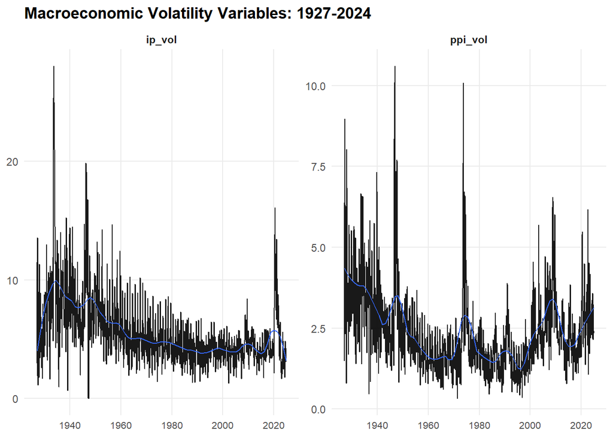

```r
  ## Macro variables
  macro_1927_vars     <- c("ppi_vol", "ip_vol")
  plot_macro_1927 <- plot_ts_grid(
        covariates_1927_df, macro_1927_vars, ncol = 3,
        title = "Macroeconomic Volatility Variables: 1927-2024"
      )
  print(plot_macro_1927)
```

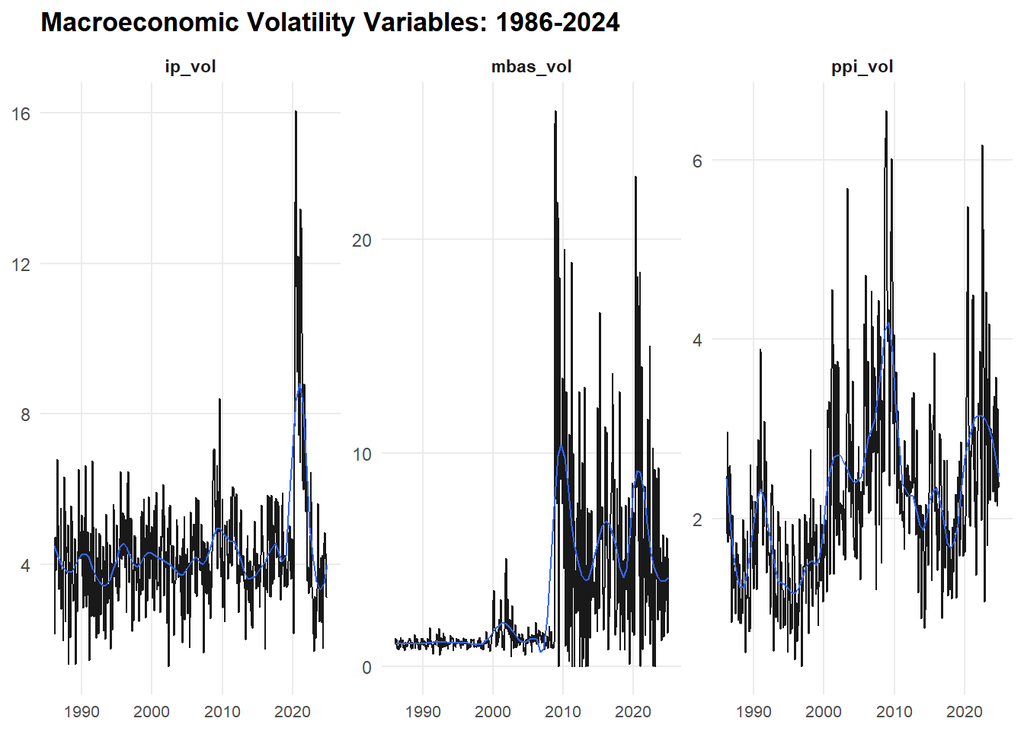

```r
  macro_1986_vars     <- c("ppi_vol", "ip_vol",  "mbas_vol")
  plot_macro_1986 <- plot_ts_grid(
        covariates_1986_df, macro_1986_vars, ncol = 3,
        title = "Macroeconomic Volatility Variables: 1986-2024"
      )
  print(plot_macro_1986)
```

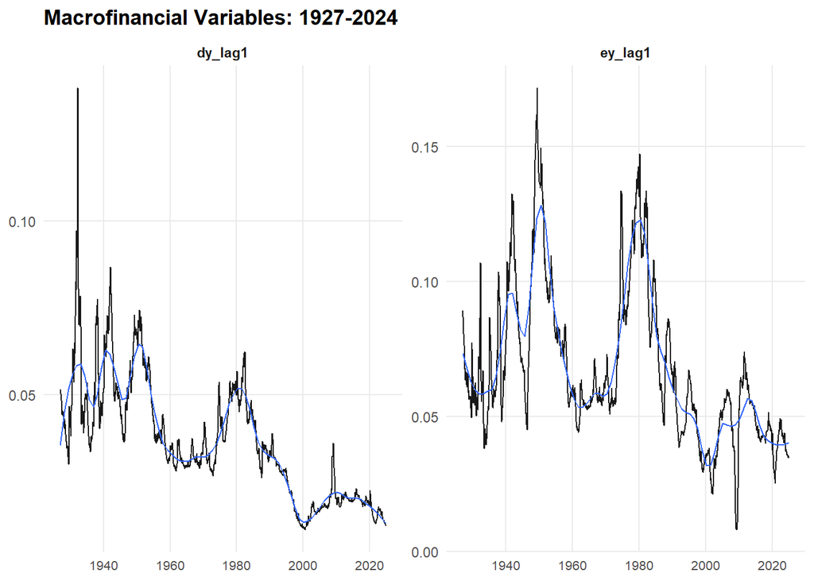

```r
  ## Macrofinancial variables
  macro_fin_1927_vars <- c("dy_lag1", "ey_lag1")
  plot_macro_fin_1927 <- plot_ts_grid(
    covariates_1927_df, macro_fin_1927_vars, ncol = 2,
    title = "Macrofinancial Variables: 1927-2024"
    )
  print(plot_macro_fin_1927)
```

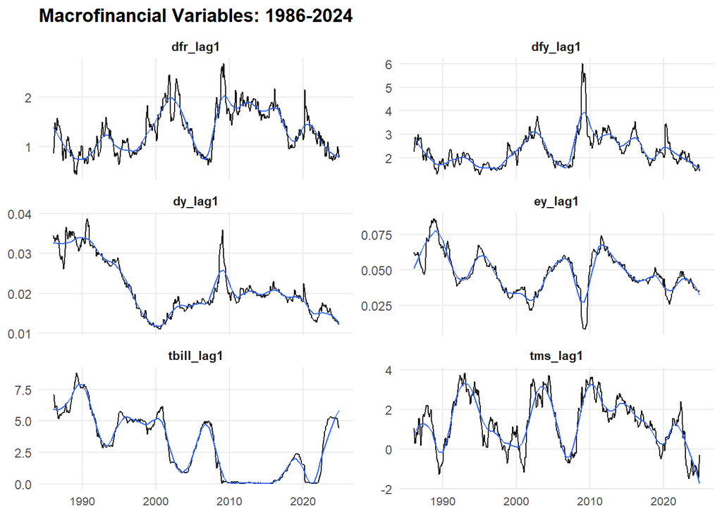

```r
  macro_fin_1986_vars <- c("dy_lag1", "ey_lag1", "dfr_lag1", "dfy_lag1",
                           "tms_lag1", "tbill_lag1")
  plot_macro_fin_1986 <- plot_ts_grid(
        covariates_1986_df, macro_fin_1986_vars, ncol = 2,
        title = "Macrofinancial Variables: 1986-2024"
      )
  print(plot_macro_fin_1986)
```

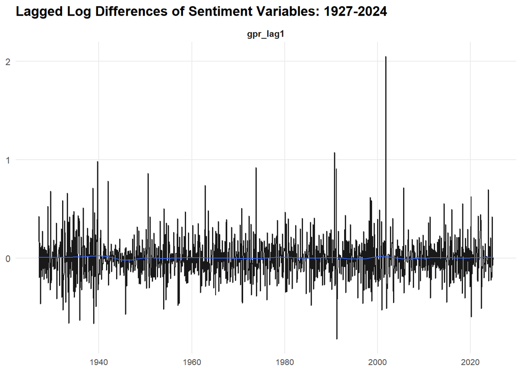

```r
  ## Sentiment variables
  sent_1927_vars      <- c("gpr_lag1")
  plot_sent_1927 <- plot_ts_grid(
        covariates_1927_df, sent_1927_vars, ncol = 1,
        title = "Lagged Log Differences of Sentiment Variables: 1927-2024"
      )
  print(plot_sent_1927)
```

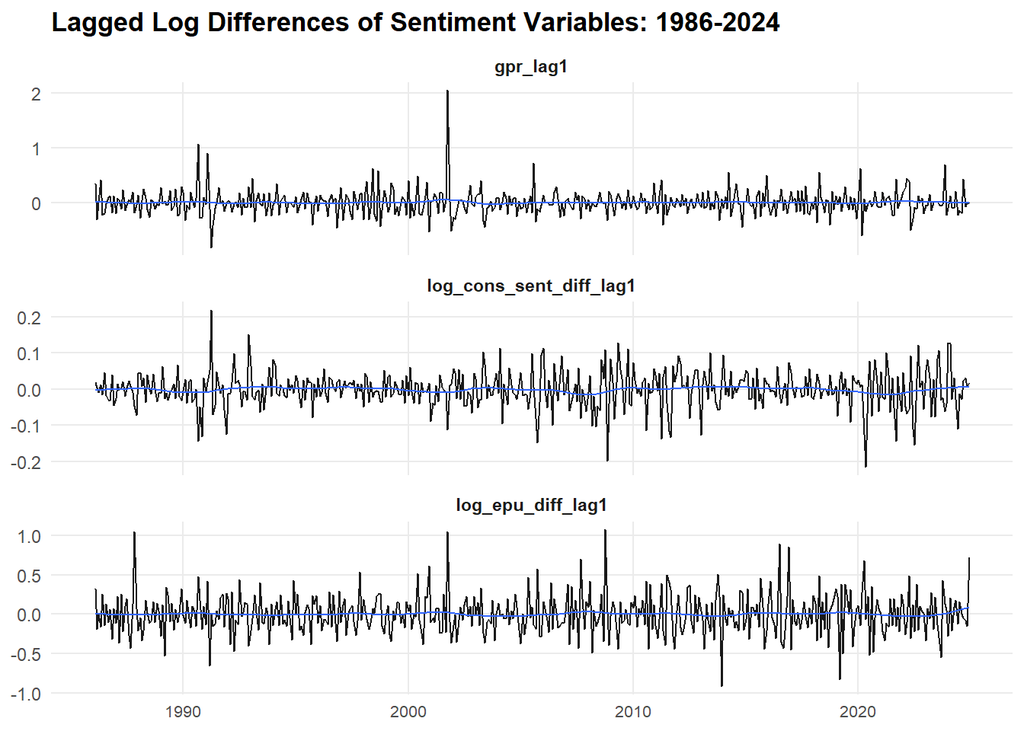

```r
  sent_1986_vars      <- c("gpr_lag1", "log_cons_sent_diff_lag1",
                           "log_epu_diff_lag1")
  plot_sent_1986 <- plot_ts_grid(
        covariates_1986_df, sent_1986_vars, ncol = 1,
        title = "Lagged Log Differences of Sentiment Variables: 1986-2024"
      )
  print(plot_sent_1986)
```

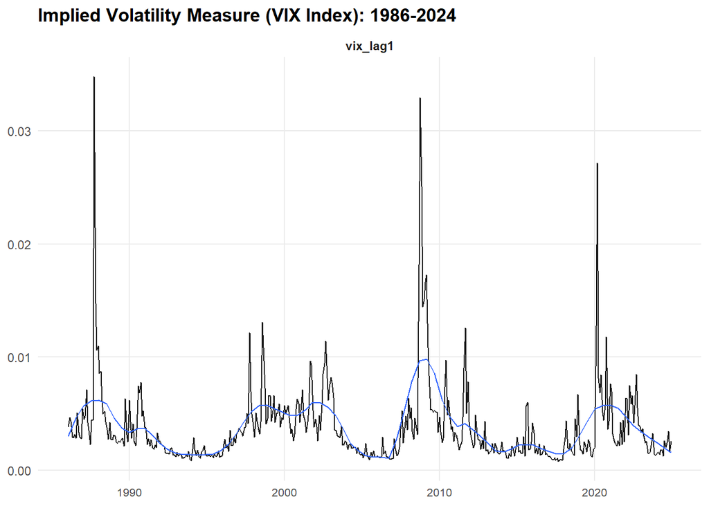

```r
  ## Implied volatility
  implied_vol    <- c("vix_lag1")
  plot_implied_vol_1986 <- plot_ts_grid(
    covariates_1986_df, implied_vol, ncol = 1,
    title = "Implied Volatility Measure (VIX Index): 1986-2024"
    )
  print(plot_implied_vol_1986)
```

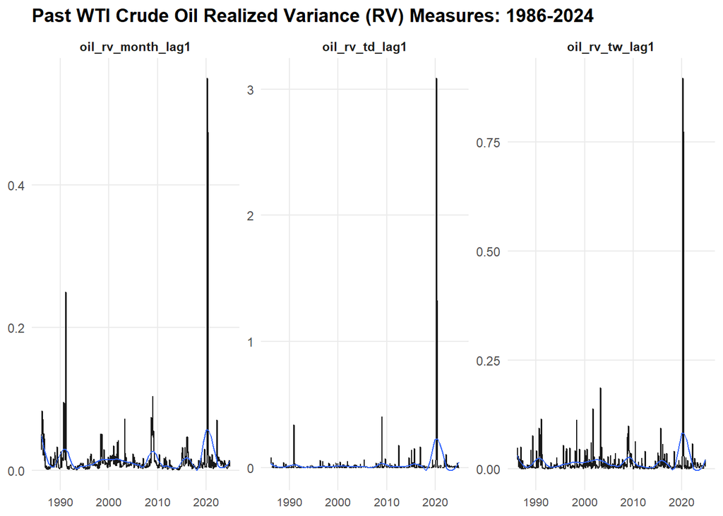

```r
  ## WTI Past RV terms
  rv_vars_oil   <- c("oil_rv_month_lag1", "oil_rv_tw_lag1", "oil_rv_td_lag1")
  plot_oil_rv_1986 <- plot_ts_grid(
    covariates_1986_df, rv_vars_oil, ncol = 3,
    title = "Past WTI Crude Oil Realized Variance (RV) Measures: 1986-2024"
    )
  print(plot_oil_rv_1986)
```

By observing the series and, in special the decomposition in continuous and jump parts, we can notice some periods of spikes in RV, such as during the Great Depression (1929-1933), the second World War (1939-1945), the Dot-com Bubble burst (2000-2002), the Global Financial Crisis (2007-2009) and the COVID-19 pandemic (2020).

Regarding sentiment variables, we can notice relevant spikes in lagged log differences of GPR during the two world wards, the Cuban Missile Crisis and after the 9/11 attacks, this last also accompanied by increases in EPU. The lagged log differences of EPU also show relevant spikes during the GFC, accompanied by a significant negative shock in lagged log differences of Consumer Sentiment Index, and also more recently, with a significant increase in 2024.

Looking at implied volatility (VIX Index), we can notice high levels at the second half of the 1980s, during the 1987 stock market crash, followed by a downward trend until the Dot-com Bubble burst, when we can see a relevant spike. After that, there is a downward trend until the GFC, when we can see another spike. After that, there is a downward trend until 2020, when we can see another spike related to the COVID-19 pandemic. And finally, for the past RV terms from WTI Crude Oil market, we can notice relevant spikes in the late 1980s and beginning of the 1990s, another one in the late 1990s, during the Asian Financial Crisis, another one during the GFC, and finally another very significant one during the COVID-19 pandemic.

## Methodology

Before fitting models, I preprocessed the series following a traditional MLOps pipeline applied to time-series context. First, I impute missing variables (existent only for the WTI Oil RV terms) using Last Observation Carried Forward (LOCF) method. Then I apply winsorization at 1% and 99% levels to mitigate the effects of outliers. Finally, I standardize all covariates to have zero mean and unit standard deviation, in order to make coefficients comparable in models, to help in convergence of algorithms, and also to help with non-stationarity issues. It is important to notice that all preprocessing methods utilize only point-in-time information, ie only the past data that would be available at each point in time is used in the transformations in a expanding window format, in order to avoid forward-looking bias. As for the target variable, I applied Box-Cox transformation, estimating the lambda parameter with maximum likelihood method on an expanding window approach, which, in fact, lead to a lambda very close to 0, thus boiling down to a log-transformation. This helps with stabilizing variance and mitigating non-stationarity issues.

Training scheme involved splitting the series in three sets: training, validation and testing. Following a walk-forward approach, usual in financial time series, I used an initial training set of 10 years (120 months) and a validation set of 5 years (60 months), refitting the models and tuning hyperparameters once in a year in June, to help with scaling down usage of computational resources. At each step, I find the best hyperparameters with the help of Bayesian Optimization, which consists of a sequential model-based optimization method that uses a surrogate model to approximate the objective function and an acquisition function to guide the search for the optimal hyperparameters. Contrary to grid-search and random-search tuning methods, Bayesian Optimization uses information from previous evaluations to make informed decisions about where to sample next, thus being more efficient in finding optimal hyperparameters, especially when the objective function is expensive to evaluate, which tends to be the case for more complex algorithms. As for acquisition function, I used UCB (Upper Confidence Bound), which balances exploration and exploitation by considering both the predicted mean and uncertainty of the surrogate model. The hyperparameter search space for each algorithm is detailed in the next sections, but, in general terms, given the relative few number of observations due to the monthly frequency, I erred on the side of smaller search spaces in order to avoid overfitting during hyperparameter tuning.

Therefore, the scheme involves using the training set to estimate parameters, fitting multiple models according to the BO procedure and using the validation sample to evaluate performance and select the best hyperparameters. In special, I used rmse (Root Mean Squared Error) as the evaluation metric, but also computed mae (Mean Absolute Error), mape (Mean Absolute Percentage Error), mphe (Mean Pseudo-Huber Error with a huber delta of 1), rss (Out-of-Sample R²), and mpe (Mean Pinball Error with a tau of 0.5). The mphe behaves as a combination of quadratic and linear functions, with the transition guided by the delta parameter. This makes the metric treat small errors using quadratic loss, which is sensitive to outliers, while larger errors are treated with linear loss, which is more robust to outliers. Diferrently from the traditional huber error, the pseudo-huber has no kinks, being infinitely differentiable. As for mpe, it is calculated based on the pinball loss function, which is particularly useful for evaluating quantile forecasts. By calibrating the tau, one can encode assymetric costs to under-predicting and over-predicting, which can be specially useful in the task of predicting RV, as under-predicting it can be more costly to the investor than under-predicting. The metric is also robust to outliers. As mentioned, at this step, I used rmse for model selection, but this can be relaxed in other runs. As for objective function, some algorithms, such as XGBoost and Neural Networks, allow for implementation of Pseudo-Huber and Pinball losses, which inherently introduces the robust and assymetric aspects in traning, but, for the moment, I used traditional squared error losses.

After finding best hyperparameters, the model is refit using both training and validation sets, and thus 1-month ahead predictions are computed for the test set. It is important to notice that there is no intersection at all between training, validation and test sets, in order to avoid data leakage.

As for the models, I fitted the following algorithms so far:

- HAR: This is the Heterogeneous Autoregressive model for Realized Volatility proposed by Corsi (2009), estimated with OLS. It serves as a benchmark model in the volatility literature. The model uses lagged realized volatility terms at different horizons (daily, weekly and monthly) to capture the heterogeneous nature of market participants and their impact on volatility dynamics. It assumes a linear relationship between the covariates and the target variable, being simple to implement and interpret, but may not capture complex relationships in the data.
- Elastic Net Regression (ENet): This combines both L1 and L2 penalties in the loss function, allowing for a balance between Ridge and Lasso regressions. It is particularly useful when there are many features and they are significantly correlated, which can introduce multicollinearity issues in OLS regression. The Elastic Net can effectively handle such situations with L1 and L2 penalties that allow for regularization of coefficients and feature selection. The hyperparameters to be tuned are the regularization strength (lambda) and the mixing parameter (alpha), which controls the balance between L1 and L2 penalties. However, instead of fitting a single lambda for each model, I used a path of 100 lambdas generated by the glmnet package, and thus the hyperparameter to be tuned is actually the smallest value for lambda as a fraction of the maximum lambda (lambda_min_ratio), the data derived value that shrinks all coefficients to zero. Specifying a whole path of lambdas helps in improving model stability and performance. For the search space, I used: lambda_min_ratio: continuous [0.0001, 0.01], alpha: continuous [0, 1]. BO process was initialized with 5 random points, and then run for 10 iterations, sampling the function 2 times at each epoch. The process was run in parallel with the support of the glmnet package.
- Random Forest (RF): This is an ensemble learning method that constructs multiple decision trees during training and outputs the average prediction of individual trees. It can capture non-linear relationships and interactions between features. The hyperparameters to be tuned include number of trees (num.trees), maximum depth of trees (max.depth), the proportion of features to consider at each split (mtry), and minimal terminal node size (min.bucket), such that no nodes smaller than this value can occur. A higher number of trees generally leads to better out-of-sample performance, as we rely less on the predictions on possibly overfit individual trees, thus reducing variance in predictions, but also increases computational costs. As for max.depth, num.trees and min.bucket, they control the complexity of the individual trees, with deeper trees and smaller terminal nodes being able to capture more complex patterns, but also being more prone to overfitting. The hyperparameter search space used was: num.trees: integer [300, 1500], max.depth: integer [3, 16], mtry: continuous [0.1, 0.9] x the number of features, min.bucket: integer [1, 6]. BO process was initialized with 10 random points, and then run for 25 iterations, sampling the function 20 times at each epoch. The process was run in parallel with the support of the ranger package.
- Extreme Gradient Boosting (XGBoost): This is another ensemble learning method that builds decision trees sequentially, with each tree trying to correct errors made by previous trees, by effectively being fit on the residuals of prior trees. It gained a lot of popularity in recent years due to its strong performance in various machine learning competitions and practical applications. The hyperparameters to be tuned include number of trees (nrounds), learning rate (eta), maximum depth of trees (max_depth), minimum sum of instance weight needed in a child node (min_child_weight), subsample ratio of the training instances (subsample), column subsample ratio (colsample_bytree), alpha (L1 regularization term on weights), and gamma (minimum loss reduction required to make a further partition on a leaf onde of the tree). The learning rate controls how much each tree contributes to the final prediction, with lower values leading to more conservative models but requiring more trees. Maximum depth controls the complexity of individual trees, with deeper trees being able to capture more complex patterns but also being more prone to overfitting. The min_child_weight parameter helps in controlling overfitting by specifying the minimum sum of instance weight needed in a child node, thus preventing the model from creating nodes that are too specific to the training data. The subsample and colsample_bytree parameters help in reducing overfitting by introducing randomness in the training process and reducing number of features used. The regularization term (alpha) help in controlling overfitting by penalizing large weights and, finally, the gamma parameter helps in controlling tree complexity by requiring a minimum loss reduction for further splits, thus controlling the number of partitions in the tree. An early stopping mechanism was also implemented, such that if the validation rmse does not improve after 30 rounds, the training is stopped early to prevent overfitting. The hyperparameter search space used was: nrounds: integer [150, 800], eta: continuous [0.05, 0.20], max_depth: integer [2, 5], subsample: continuous [0.60, 0.95], colsample_bytree: continuous [0.60, 0.95], alpha: continuous [0, 2], gamma: continuous [0, 5], min_child_weight: integer [2, 10]. BO process was initialized with 12 random points, and then run for 12 iterations, sampling the function 8 times at each epoch. The process was run in parallel with the support of the xgboost package.
- Neural Networks (NN): So far, I only implemented a neural network with an architecture consisting of a single hidden layer (also known as a single-layer feedforward neural network or a shallow neural network). The plan is to expand to deeper architectures in the future, going up to 3 hidden layers or even deeper, depending on computational resources and progress in model performance. The single hidden layer architecture is a good starting point, as it can capture non-linear relationships in the data while still being relatively cheap. Following the pyramid rule of thumb for defining the number of neurons in the hidden layer, I set the number of neurons to 32, and the other architectures will use a progressively smaller number of neurons per layer. I opted for the traditional Adam optimizer for training the neural network, which is an adaptive learning rate optimization algorithm that has been widely adopted due to its efficiency and effectiveness in training deep learning models. Adam combines the advantages of two other popular optimization algorithms, AdaGrad and RMSProp, by maintaining per-parameter learning rates that are adapted based on the first and second moments of the gradients. This allows Adam to perform well on a wide range of problems and datasets, making it a suitable choice for training neural networks in various applications. The traditional ReLu (Rectified Linear Unit) activation function was used in the hidden layer, which is defined as f(x) = max(0, x). ReLu has become the default choice for activation functions in many neural network architectures due to its simplicity and effectiveness in mitigating the vanishing gradient problem, allowing for faster training and improved performance in deep networks. For the output layer, a linear activation function was used, which is appropriate for regression tasks where the goal is to predict continuous values. Finally, the architecture also involved batch normalization after the hidden layer, which is a technique used to improve the training of deep neural networks by normalizing the inputs of each layer. Batch normalization helps in stabilizing and accelerating the training process by reducing internal covariate shift, allowing for higher learning rates and reducing the sensitivity to weight initialization. It also acts as a regularizer, potentially reducing the need for other forms of regularization such as dropout. As for hyperparameters, I considered dropout, which is a regularization technique that randomly sets a fraction of input units to zero during training, helping to prevent overfitting by encouraging the network to learn more robust features, learning rate (lr), which controls how much the weights are updated during training, L1 and L2 regularizers, which help prevent overfitting by penalizing large weights and encouraging the network to learn simpler patterns, number of epochs (epochs), which determines how many times the entire training dataset is passed through the network during training, with more epochs allowing for more learning but also increasing the risk of overfitting if set too high, and batch size (batch_size), which defines the number of samples that will be propagated through the network before updating the weights. When batch size is 1, it is known as stochastic gradient descent, while larger batch sizes lead to more stable gradient estimates but require more memory. An early stopping mechanism was also implemented, such that if the validation rmse does not improve after 20 epochs, the training is stopped early to prevent overfitting. The hyperparameter search space used was: droprate: continuous [0.0, 0.4], lr: continuous [0.0001, 0.03], regularizer_l1: continuous [0.0, 0.00001], regularizer_l2: continuous [0.000001, 0.005], epochs: integer [80, 300], batch_size: integer [8, 32]. BO process was initialized with 10 random points, and then run for 20 iterations, sampling the function 4 times at each epoch. The process was run with the support of the keras package.

As for interpretability, I implemented the global surrogate model approach. This consists of fitting an interpretable model, such as OLS, on the predictions of the more complex “black-box” model, using the same features as the complex model. This surrogate model can then be used to understand the relationships learned by the black-box model, providing insights into feature importance and interactions. Although this approach does not provide local interpretability (ie, explanations for individual predictions), it can still offer valuable insights into the overall behavior of the model and the relative importance of different features in predicting the target variable.

## Preliminary results

For the 1927-2024 subset, evaluation metrics on the test set are presented below. Resultes are encapsulated in a S4 class “wf_backtest_results”, which contains evaluation metrics on both testing and validation samples, out-of-sample outputs, hyperparameters choices and iterations throughout the walk-forward procedure, the final model object, encapsulated in a S4 class “rv_model”, a OLS global surrogate model fitted on the entire training+validation set for interpretability purposes, and, finally, some metadata, such as a backtest identifier and a list of the arguments and timestamps used in the backtest. Both the “wf_backtest_results” and the “rv_model” classes incorporate methods, such as printing, summary, plotting and predicting, this one only for the “rv_model” class, effectively providing an unique serving interface for all models.

```r
 ## Load model results
 har_backtest_res    <- readRDS(file.path(here::here(),
                                          "models",
                                          "har_backtest_res.rds"))
 glmnet_backtest_res <- readRDS(file.path(here::here(),
                                          "models",
                                          "glmnet_backtest_res.rds"))
 rf_backtest_res     <- readRDS(file.path(here::here(),
                                          "models",
                                          "rf_backtest_res.rds"))
 xgb_backtest_res    <- readRDS(file.path(here::here(),
                                          "models",
                                          "xgb_backtest_res.rds"))
 nn1_backtest_res    <- readRDS(file.path(here::here(),
                                          "models",
                                          "nn1_backtest_res.rds"))
```

The out-of-sample consolidated evaluation metrics are as follows:

```r
  ##Extract all results into a single table
  eval_metrics <- c("rss", "rmse", "mae", "mphe", "mpe", "mape")
  models <- list(
    HAR    = har_backtest_res@eval_metrics,
    GLMNET = glmnet_backtest_res@eval_metrics,
    RF     = rf_backtest_res@eval_metrics,
    XGB    = xgb_backtest_res@eval_metrics,
    NN1    = nn1_backtest_res@eval_metrics
  )
    ### Prepare each table
    tbls <- purrr::imap(
      models,
      ~ .x %>%
        dplyr::filter(metric %in% eval_metrics) %>%
        dplyr::select(metric, cons_oos) %>%
        dplyr::mutate(cons_oos = round(cons_oos, 4)) %>%
        dplyr::rename(!!.y := cons_oos)
    )

    ### Use purrr::reduce to iteratively join data frames
    out <- purrr::reduce(tbls, ~ dplyr::full_join(.x, .y, by = "metric")) %>%
      dplyr::mutate(metric = factor(metric, levels = eval_metrics)) %>%
      dplyr::arrange(metric)

    print(out)
```

```
## # A tibble: 6 × 6
##   metric   HAR GLMNET     RF    XGB    NN1
##   <fct>  <dbl>  <dbl>  <dbl>  <dbl>  <dbl>
## 1 rss    0.056  0.307 0.400  0.400  -0.101
## 2 rmse   0.897  0.769 0.716  0.715   0.969
## 3 mae    0.657  0.597 0.556  0.556   0.771
## 4 mphe   0.270  0.225 0.199  0.199   0.336
## 5 mpe    0.328  0.299 0.278  0.278   0.386
## 6 mape   0.101  0.092 0.0857 0.0853  0.116
```

A similar pattern can be observed for other evaluation metrics, with RF and XGBoost competing for the best performance, and both outperforming HAR by a significant margin. Elastic Net regression also outperformed HAR under all metrics, but underperformed both RF and XGBoost by a relevant margin. This shows that non-linearities and interactions between features are important in modeling monthly realized volatility, which is expected given the complex nature of the data generating processes in financial markets.

Below I discuss the models in more detail:

### Elastic Net

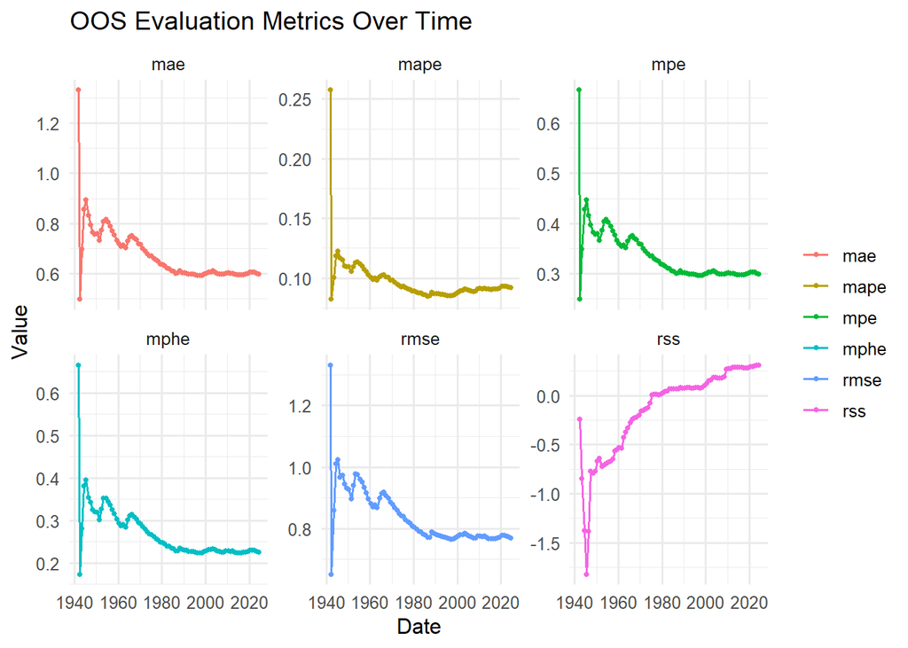

```r
  ## Covariates Themes
   theme_map <- data.frame(
         feat = c("rv_month_lag1", "rv_tw_lag1", "rv_td_lag1",
                  "rq_month_lag1", "rq_tw_lag1", "rq_td_lag1",
                  "cont_month_lag1", "cont_tw_lag1", "cont_td_lag1",
                  "jump_month_lag1", "jump_tw_lag1", "jump_td_lag1",
                  "negret_month_lag1", "negret_tw_lag1", "negret_td_lag1",
                  "log_epu_diff_lag1", "gpr_lag1",
                  "ppi_vol", "ip_vol",
                  "dy_lag1", "ey_lag1",
                  "month", "sqrt_days"),
         theme = c(rep("Past S&P 500 RV Terms", 15),
                   rep("Sentiment Variables", 2),
                   rep("Macroeconomic Variables", 2),
                   rep("Macrofinancial Variables", 2),
                   rep("Calendar Variables", 2)
         )
       )

  ## All Evaluation Metric Over Time
  invisible(plot(glmnet_backtest_res, plot_id = 3,
                 metrics_to_plot = eval_metrics))
```

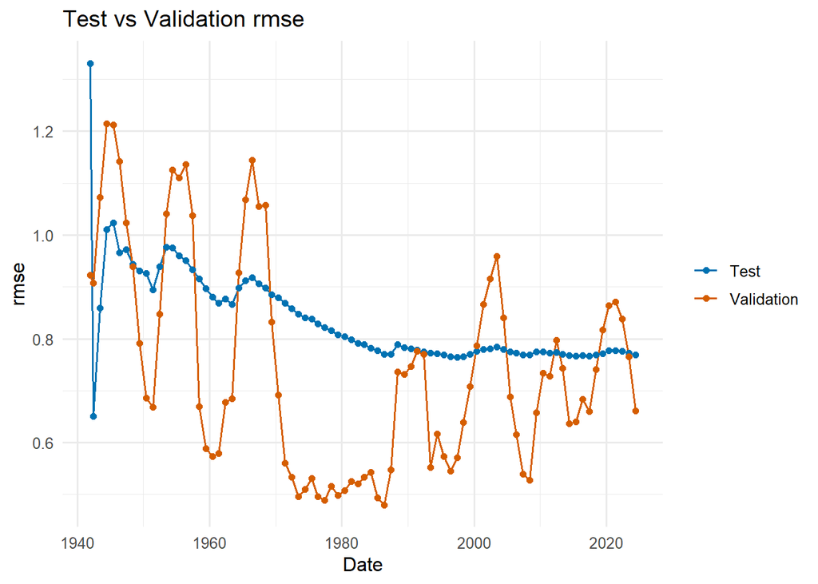

```r
  ## Test vs Validation Chosen Evaluation Metrics Over Time
  invisible(plot(glmnet_backtest_res, plot_id = 2))
```

```r
  cat("Validation metrics at Hyperparameters chosen\n")
```

```
## Validation metrics at Hyperparameters chosen
```

```r
  summary(glmnet_backtest_res, summary_id = 3)
```

```
## Backtest ID: glmnet_2025-10-15_10-10-51.458784_rmse_squared_error
```

```
##
## Validation Metrics at Hyper-Choice - Summary
## | Metric |    Mean |  Median |     SD |     Min |     Max |
## | ------ | ------- | ------- | ------ | ------- | ------- |
## |   cp   | 46.1055 | 45.8785 | 5.0711 | 35.8913 | 56.7870 |
## |   hr   |  1.0000 |  1.0000 | 0.0000 |  1.0000 |  1.0000 |
## |  mae   |  0.6000 |  0.5487 | 0.1915 |  0.3554 |  1.0628 |
## | mape   |  0.0917 |  0.0872 | 0.0270 |  0.0548 |  0.1542 |
## |   mb   | -0.1114 | -0.0136 | 0.3892 | -0.9772 |  0.6935 |
## |  mpe   |  0.3000 |  0.2744 | 0.0958 |  0.1777 |  0.5314 |
## | mphe   |  0.2281 |  0.1880 | 0.1141 |  0.0989 |  0.5185 |
## | rmse   |  0.7469 |  0.6995 | 0.2045 |  0.4795 |  1.2148 |
## |  rss   | -0.0297 |  0.1715 | 0.6785 | -2.4151 |  0.6981 |
```

```r
  cat("Hyperparameters Chosen Over Time - Summary\n")
```

```
## Hyperparameters Chosen Over Time - Summary
```

```r
  summary(glmnet_backtest_res, summary_id = 4)
```

```
## Backtest ID: glmnet_2025-10-15_10-10-51.458784_rmse_squared_error
##
## Hyperparameters Chosen Over Time - Summary
## | Hyperparameter   | N_Obs | Unique_Values | Most_Common          | Last_Value |
## | ---------------- | ----- | ------------- | -------------------- | ---------- |
## |            alpha |    84 |            23 |                    1 |     0.5474 |
## | lambda.min.ratio |    84 |            31 |                1e-04 |     0.0001 |
## |         best_lam |    84 |            84 | 0.000168332241700052 |     0.0004 |
```

```r
  ## Feature Importance
  cat("Consolidated Feature Importance\n")
```

```
## Consolidated Feature Importance
```

```r
  summary(glmnet_backtest_res, summary_id = 6)
```

```
## Backtest ID: glmnet_2025-10-15_10-10-51.458784_rmse_squared_error
##
## Final Feature Importance — Last Model
## | Covariate         | Final_Feature_Imp |
## | ----------------- | ----------------- |
## |         sqrt_days |            0.5457 |
## |               m_9 |            0.2946 |
## |               m_1 |            0.2945 |
## |              m_11 |            0.2904 |
## |               m_6 |            0.2784 |
## |               m_2 |            0.2668 |
## |              m_10 |            0.2372 |
## |               m_4 |            0.2172 |
## |               m_5 |            0.2141 |
## |           dy_lag1 |            0.2128 |
## |               m_3 |            0.1871 |
## |               m_8 |            0.1866 |
## |               m_7 |            0.1741 |
## |           ppi_vol |            0.1727 |
## |   cont_month_lag1 |            0.1717 |
## |   jump_month_lag1 |            0.1411 |
## |      cont_tw_lag1 |            0.1306 |
## |      jump_tw_lag1 |            0.1255 |
## |        rv_tw_lag1 |            0.1247 |
## |          gpr_lag1 |            0.1224 |
## |        rq_td_lag1 |            0.1082 |
## |      jump_td_lag1 |            0.1080 |
## |    negret_td_lag1 |            0.1080 |
## |    negret_tw_lag1 |            0.1080 |
## | negret_month_lag1 |            0.1080 |
## |     rq_month_lag1 |            0.1074 |
## |        rq_tw_lag1 |            0.1032 |
## |        rv_td_lag1 |            0.1031 |
## |      cont_td_lag1 |            0.1022 |
## |            ip_vol |            0.0923 |
## | log_epu_diff_lag1 |            0.0772 |
## |     rv_month_lag1 |            0.0757 |
## |           ey_lag1 |            0.0441 |
## |              m_12 |            0.0000 |
## |       (Intercept) |           -5.6334 |
```

```r
  cat("Feature Importance Over Time\n")
```

```
## Feature Importance Over Time
```

```r
  summary(glmnet_backtest_res, summary_id = 5)
```

```
## Backtest ID: glmnet_2025-10-15_10-10-51.458784_rmse_squared_error
##
## Feature Importance — Summary
## | Covariate         | Mean_Feature_Imp | Median_Feature_Imp |     Q25 |     Q75 |     Max |     Min |
## | ----------------- | ---------------- | ------------------ | ------- | ------- | ------- | ------- |
## |       (Intercept) |          -5.4884 |            -5.6439 | -5.6518 | -5.6247 | -0.0102 | -5.6592 |
## |   cont_month_lag1 |           0.1755 |             0.1685 |  0.1513 |  0.1799 |  0.6142 |  0.1064 |
## |      cont_td_lag1 |           0.1298 |             0.1367 |  0.1020 |  0.1550 |  0.2181 |  0.0807 |
## |      cont_tw_lag1 |           0.1715 |             0.1546 |  0.1416 |  0.1686 |  0.6499 |  0.0705 |
## |           dy_lag1 |           0.2546 |             0.2021 |  0.1914 |  0.2184 |  1.1010 |  0.1660 |
## |           ey_lag1 |           0.0577 |             0.0718 |  0.0436 |  0.1470 |  0.1667 | -0.8027 |
## |          gpr_lag1 |           0.1524 |             0.1457 |  0.1259 |  0.1583 |  0.3672 |  0.1146 |
## |            ip_vol |           0.1365 |             0.1473 |  0.1108 |  0.1589 |  0.1954 |  0.0095 |
## |   jump_month_lag1 |           0.1778 |             0.1660 |  0.1409 |  0.1803 |  0.5107 |  0.1250 |
## |      jump_td_lag1 |           0.1374 |             0.1400 |  0.1085 |  0.1579 |  0.2181 |  0.0964 |
## |      jump_tw_lag1 |           0.1519 |             0.1458 |  0.1254 |  0.1597 |  0.4843 |  0.0843 |
## | log_epu_diff_lag1 |           0.1162 |             0.1256 |  0.0832 |  0.1507 |  0.1661 | -0.0273 |
## |               m_1 |           0.1466 |             0.1679 |  0.1564 |  0.1815 |  0.2974 | -0.5714 |
## |              m_10 |           0.2730 |             0.1951 |  0.1733 |  0.2375 |  1.7861 |  0.1543 |
## |              m_11 |           0.2167 |             0.2115 |  0.1668 |  0.2936 |  0.4150 | -0.7910 |
## |              m_12 |           0.0000 |             0.0000 |  0.0000 |  0.0000 |  0.0000 |  0.0000 |
## |               m_2 |           0.1003 |             0.1762 |  0.1618 |  0.2671 |  0.3298 | -2.2481 |
## |               m_3 |           0.1989 |             0.1753 |  0.1640 |  0.1915 |  0.7605 |  0.1537 |
## |               m_4 |           0.1881 |             0.1803 |  0.1664 |  0.1969 |  0.3624 |  0.1395 |
## |               m_5 |           0.1917 |             0.1806 |  0.1675 |  0.2024 |  0.4688 |  0.1537 |
## |               m_6 |           0.2530 |             0.2105 |  0.1687 |  0.2809 |  0.9366 |  0.1543 |
## |               m_7 |           0.1691 |             0.1777 |  0.1656 |  0.1966 |  0.2340 | -0.2981 |
## |               m_8 |           0.1488 |             0.1627 |  0.1540 |  0.1711 |  0.2148 | -0.1741 |
## |               m_9 |           0.3142 |             0.2957 |  0.1810 |  0.3889 |  0.9506 |  0.1543 |
## | negret_month_lag1 |           0.1374 |             0.1400 |  0.1085 |  0.1579 |  0.2181 |  0.0964 |
## |    negret_td_lag1 |           0.1374 |             0.1400 |  0.1085 |  0.1579 |  0.2181 |  0.0964 |
## |    negret_tw_lag1 |           0.1374 |             0.1400 |  0.1085 |  0.1579 |  0.2181 |  0.0964 |
## |           ppi_vol |           0.1522 |             0.1632 |  0.1352 |  0.1702 |  0.2015 |  0.0099 |
## |     rq_month_lag1 |           0.1377 |             0.1420 |  0.1077 |  0.1585 |  0.2137 |  0.0959 |
## |        rq_td_lag1 |           0.1379 |             0.1400 |  0.1087 |  0.1579 |  0.2265 |  0.0967 |
## |        rq_tw_lag1 |           0.1341 |             0.1383 |  0.1040 |  0.1562 |  0.2014 |  0.0932 |
## |     rv_month_lag1 |           0.1303 |             0.1529 |  0.1092 |  0.1702 |  0.2269 | -0.4004 |
## |        rv_td_lag1 |           0.1023 |             0.1379 |  0.1000 |  0.1556 |  0.1826 | -0.5447 |
## |        rv_tw_lag1 |           0.1721 |             0.1497 |  0.1252 |  0.1684 |  1.0163 |  0.1038 |
## |         sqrt_days |           0.2480 |             0.5175 |  0.3496 |  0.5549 |  0.6519 | -4.2435 |
```

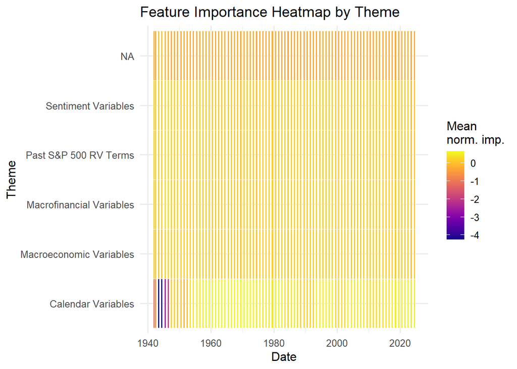

```r
  ## Feature Importance by Theme
  invisible(plot(glmnet_backtest_res, plot_id = 7, theme_map = theme_map))
```

```r
  glmnet_backtest_res@final_feat_imp %>%
    dplyr::arrange(dplyr::desc(norm_imp)) %>%
    print(n = 35)
```

```
## # A tibble: 35 × 5
##    id                           feat              dates           imp norm_imp
##    <chr>                        <chr>             <date>        <dbl>    <dbl>
##  1 sqrt_days-2024-06-01         sqrt_days         2024-06-01  8.43e-1   0.546
##  2 m_9-2024-06-01               m_9               2024-06-01  3.59e-1   0.295
##  3 m_1-2024-06-01               m_1               2024-06-01  3.59e-1   0.294
##  4 m_11-2024-06-01              m_11              2024-06-01  3.51e-1   0.290
##  5 m_6-2024-06-01               m_6               2024-06-01  3.28e-1   0.278
##  6 m_2-2024-06-01               m_2               2024-06-01  3.06e-1   0.267
##  7 m_10-2024-06-01              m_10              2024-06-01  2.49e-1   0.237
##  8 m_4-2024-06-01               m_4               2024-06-01  2.10e-1   0.217
##  9 m_5-2024-06-01               m_5               2024-06-01  2.04e-1   0.214
## 10 dy_lag1-2024-06-01           dy_lag1           2024-06-01  2.02e-1   0.213
## 11 m_3-2024-06-01               m_3               2024-06-01  1.52e-1   0.187
## 12 m_8-2024-06-01               m_8               2024-06-01  1.51e-1   0.187
```

[output cut: 23 more lines]

```r
  glmnet_backtest_res@final_feat_imp %>%
    dplyr::left_join(theme_map, by = c("feat")) %>%
    dplyr::group_by(theme) %>%
    dplyr::summarize(
      mean_imp = mean(norm_imp),
      sd_imp = sd(norm_imp)
    ) %>%
    dplyr::arrange(dplyr::desc(mean_imp)) %>%
    print()
```

```
## # A tibble: 6 × 3
##   theme                    mean_imp  sd_imp
##   <chr>                       <dbl>   <dbl>
## 1 Calendar Variables         0.546  NA
## 2 Macroeconomic Variables    0.132   0.0569
## 3 Macrofinancial Variables   0.128   0.119
## 4 Past S&P 500 RV Terms      0.115   0.0218
## 5 Sentiment Variables        0.0998  0.0320
## 6 <NA>                      -0.230   1.63
```